# Time to Play Exponential

Herein lies the answers for parts (a) through (e) of the **Time to Play** problem posed at the end of the Exponential Disribution section.

(a) Below is a sketch of the Exponential Distribution that models the Richter scale size of earthquakes that have epicenters in Southern California. For convenience, a random variable $X$ is defined to represent the Richter scale measurement of an earthquake that has its epicenter in Southern california. Note that $\mu_{x} = E(X) = 5.3$. The probability density function of $X$ is
$$f(x) = \left(\frac{1}{5.3}\right)e^{-x/5.3} \:\: \text{for} \:\; x \geq 0$$
This probability density function is mapped out below.

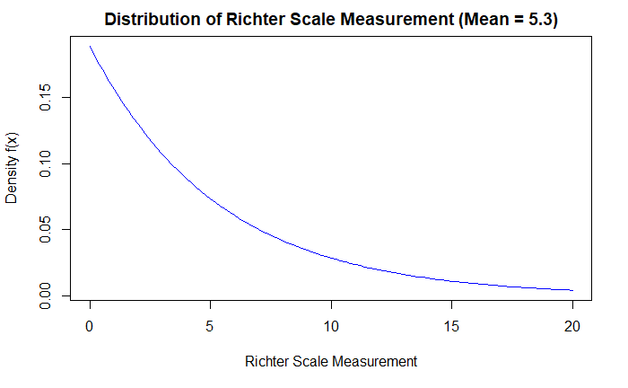

```r
curve(dexp(x, 1/5.3), 0, 20, xlab="Richter Scale Measurement", ylab="Density f(x)", main="Distribution of Richter Scale Measurement (Mean = 5.3)", col="blue")
```

2. The standard deviation of the above distribution is computed with
   $$\sigma_{X} = SD(X) = \sqrt{\beta^{2}} = \sqrt{E(X)^{2}} = \beta = 5.3$$
   The standard deviation of the above distribution is 5.3, in Richter scale units.
3. To compute $P(3 \leq X \leq 4)$, represented by the region below

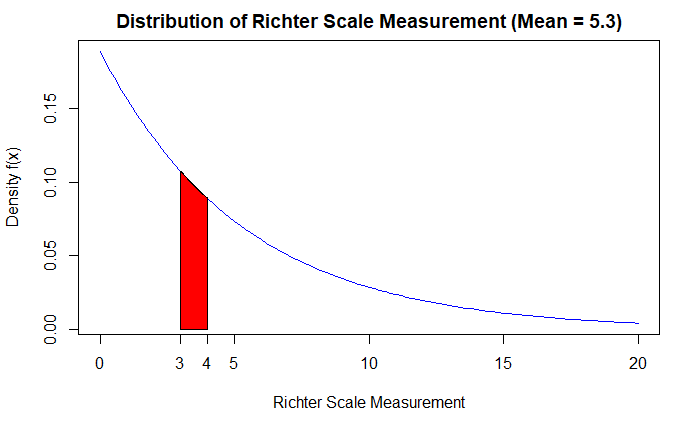

This probability is computed with the integral
$$P(3 \leq X \leq 4) = \int_{3}^{4}\left(\frac{1}{5.3}\right)e^{-x/5.3}dx = \left[-e^{-x/5.3}\right]_{3}^{4} = e^{-3/5.3} - e^{-4/5.3} = 0.09762699 \approx 0.0976$$
and is computed with R below

```r
pexp(4, 1/5.3) - pexp(3, 1/5.3) #P(X <= 4) - P(X <= 3)
```

```
[1] 0.09762699
```

The probability/chance of an earthquake with an epicenter in Southern California will have a magnitude on the Richter scale of between 3 and 4 is 0.0976, or 9.76%.

4. To compute the values of $x_{25}$, you are finding the value that satisfies the probability statement $P(X \leq X_{25}) = 0.25$. This is computed with the `qexp(percentile, 1/beta)` function in R:

```r
qexp(0.25, 1/5.3) #computes the 25th percentile of Exponential for mean = 5.3
```

```
[1] 1.524715
```

and

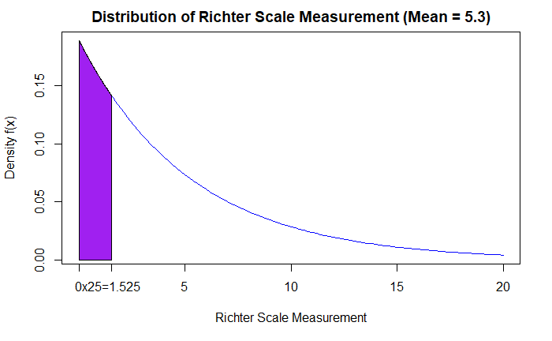

25% of all earthquakes epicented in Southern California have a magnitute of at most 1.525 on the Richter scale.

5. Similar to part (c): To compute $P(X > 6.4)$ the area of the region below is required:

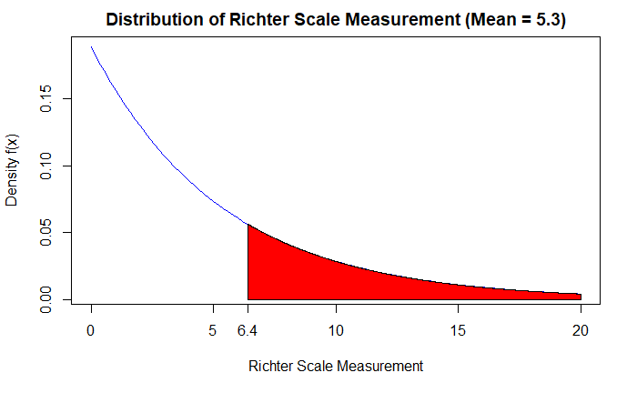

Computed with R below

```r
1 - pexp(6.4, 1/5.3)  #1 - P(Z <= 6.4)
```

```
[1] 0.2989296
```

it is found that
$$P(X \geq 6.4) = \int_{6.4}^{\infty}\left(\frac{1}{5.3}\right)e^{-x/5.3}dx = \left[-e^{-x/5.3}\right]_{6.4}^{\infty} = e^{-6.4/5.3} = 0.2989296 \approx 0.2989$$
It is quite likely, 0.2989 or 29.89%, that an earthquake epicentered in Southern California will exceed the magnitude of the Ridgecrest earthquake of July 4, 2019.

5. To compute $P(X > 7| X > 6.4)$,
   $$\begin{aligned}
   P(X > 7| X > 6.4) = & \frac{P((X > 7) \cap (X > 6.4))}{P(X > 6.4)} \\
   = & \frac{P((X > 7)}{P(X > 6.4)} \\
   = & \frac{\int_{7}^{\infty}\left(\frac{1}{5.3}\right)e^{-x/5.3}dx}{\int_{6.4}^{\infty}\left(\frac{1}{5.3}\right)e^{-x/5.3}dx} \\
   = & \frac{1 - \text{pexp}(7, 1/5.3)}{1 - \text{pexp}(6.4, 1/5.3)} \hspace{0.2in} (\text{using the R commands}) \\
   = & 0.8929653 \\
   \approx & 0.8930
   \end{aligned}$$

```r
(1 - pexp(7, 1/5.3))/(1 - pexp(6.4, 1/5.3))
```

```
[1] 0.8929653
```

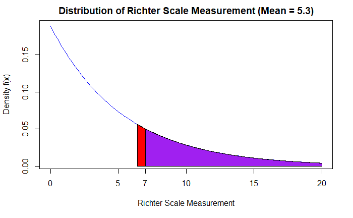

If an earthquake with an epicenter in Southern California has a magnitude of more than 6.4, the chance/probability this earthquake will exceed a magnitude of 7 is 0.8930, or 89.30%.